# Working with survey data

## Setup

```r
install.packages(c("here","gt", "gtsummary"))
```

### Creating a project directory

- Go to file `->` New Project and follow the interface to create a new project in a directory
- Call the project something like `SDSB` (or just call it `ANES recoding` if you think you might want to have separate projects for different assignments.)
- Create a new folder called `Data` inside the project directory.

### Downloading data

- Go to the ANES website and download the [cumulative time series (1948 to 2024)](https://electionstudies.org/data-center/anes-time-series-cumulative-data-file/) in `.csv` format
- Also download the same file in `.stata` format.
- Put the zip file in your `Data` directory. Don’t unzip it!

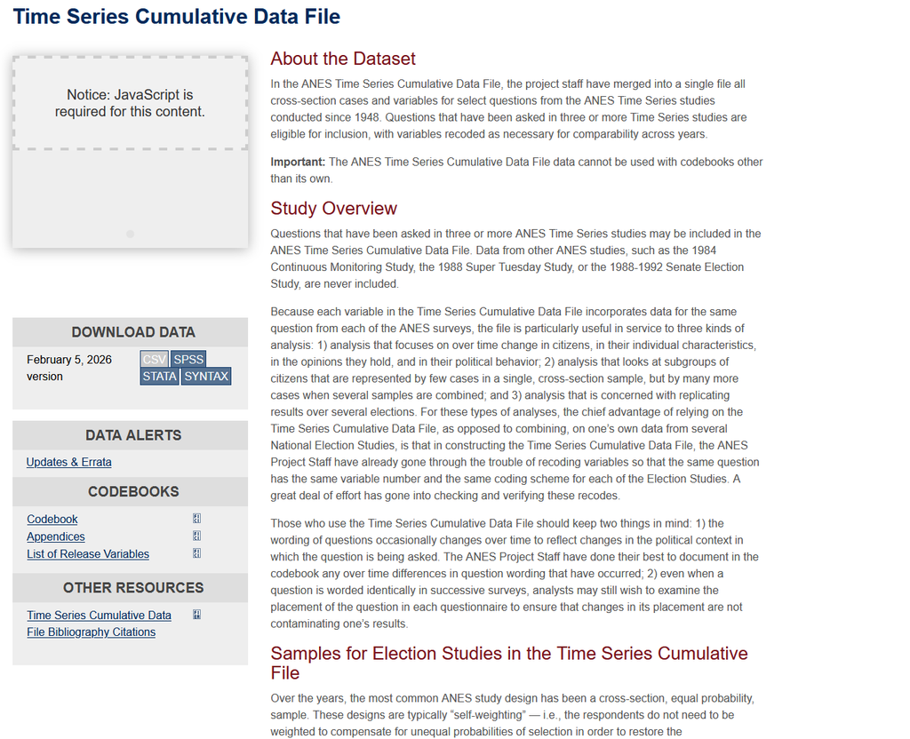

### Importing the data into R

If you have the right setup, the commands below should import the data into R and load the libraries you need for this analysis.

```r
library(tidyverse)
library(gtsummary)
library(gt)


fname<-here::here('data', 'anes_timeseries_cdf_csv_20260205.zip')
anes<-readr::read_csv(unz(fname, 'anes_timeseries_cdf_csv_20260205.csv'))
```

(`here` is a helper function that finds the root directory of the current project, which makes it easy to locate files regardless of your current working directory. )

### Checking it out

Click the data set name in the environment window to see what you’ve got. Also look in the zipped folder and look at the codebook file (labelled `anes_timeseries_cdf_codebook_var_20260205.pdf`)

### Checking it out

- This data set includes all questions that were asked in three or more rounds of the ANES, so, depending on your interests, this is a survey that can track public opinion dating all the way back to 1948.
- But to get it in a usable format, we’ll need to do some re-coding.

### Filtering some rows

Since we’re dealing with a large data set here, it might help to get rid of some rows that we won’t need (the questions we’re dealing with only become available in 1986)

```r
anes<-anes|>
  filter(VCF0004>=1986)
```

## Recoding variables

The simplest way to store survey data is with numeric codes and codebook to indicate the mapping of responses to numbers.

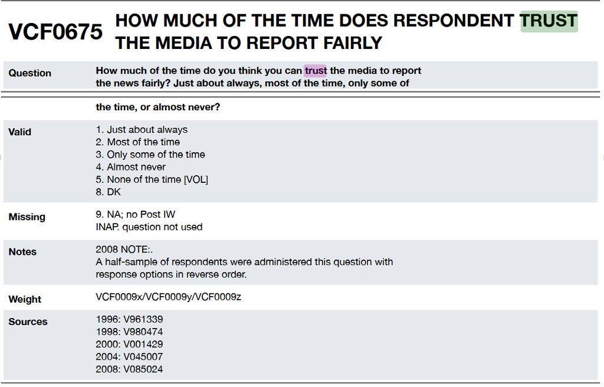

```r
anes|>
  count(VCF0675)
```

```
# A tibble: 8 × 2
  VCF0675     n
    <dbl> <int>
1       1   335
2       2  2292
3       3  3607
4       4  1140
5       5   133
6       8    23
7       9   806
8      NA 35972
```

### Recoding numeric variables

Even variables that are essentially numeric may require some recoding because non-responses will often be assigned their own numeric codes:

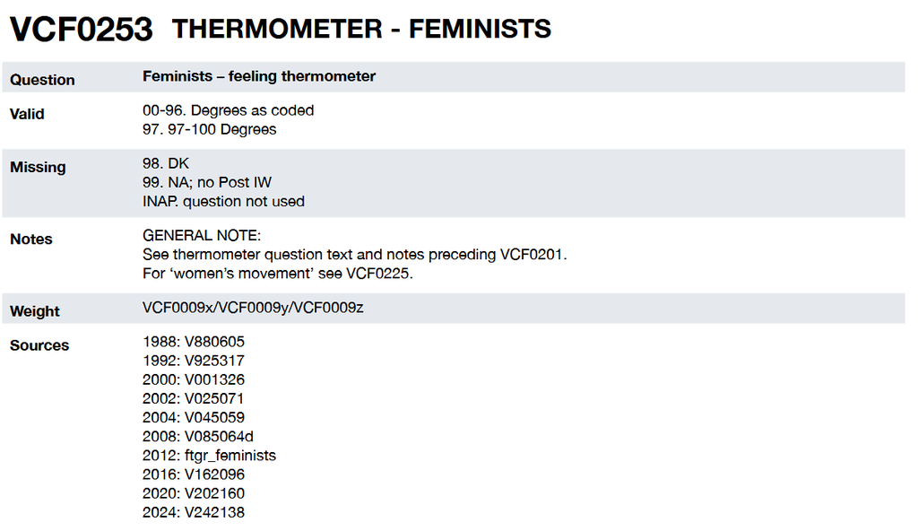

ANES feeling thermometer scores

```r
summary(anes$VCF0253)
```

```
   Min. 1st Qu.  Median    Mean 3rd Qu.    Max.    NA's
   0.00   50.00   60.00   61.05   85.00   99.00    8946
```

### Recoding numeric variables

Obviously this would give us misleading results if we treated the 98/99 codes as a numeric value, so we’ll need to replace those with actual `NA` values instead.

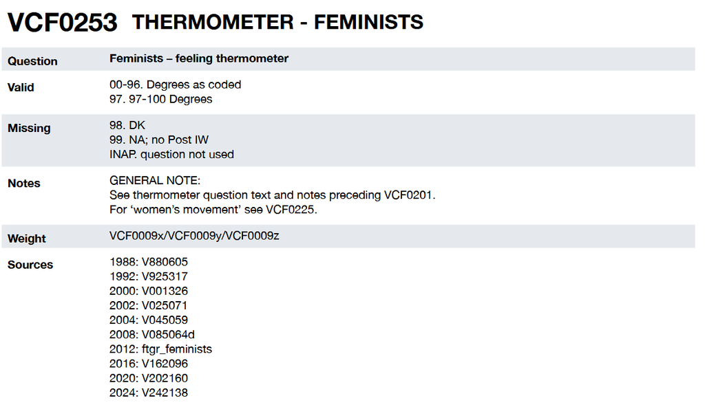

ANES feeling thermometer scores

```r
anes|>
  mutate(fem_therm = replace(VCF0253, VCF0253>97, NA))|>
  summarize(
    mean_fem_therm = mean(fem_therm, na.rm=T)

    )
```

```
# A tibble: 1 × 1
  mean_fem_therm
           <dbl>
1           56.0
```

### Recoding variables

This setup makes sense for storage and transfer, but it means we need to do some extra work to get this kind of data in a useable format for analysis. Usually, this will involve creating and manipulating factor variables.

```r
anes|>
  count(VCF0675 )
```

```
# A tibble: 8 × 2
  VCF0675     n
    <dbl> <int>
1       1   335
2       2  2292
3       3  3607
4       4  1140
5       5   133
6       8    23
7       9   806
8      NA 35972
```

### Factors

Factor variables are essentially just integers with an extra attribute that maps numbers onto text values.

```r
fvar <- factor(
  x = c(1, 1, 2, 2, 3, 3, 3),
  levels = c(1, 2 ,3),
  labels = c('A', 'B', 'C'))

fvar
```

```
[1] A A B B C C C
Levels: A B C
```

These are still basically numeric data under the hood:

```r
as.numeric(fvar)
```

```
[1] 1 1 2 2 3 3 3
```

### Creating factors

The easiest way to create a factor is using the `factor` command.

The `levels` argument specifies the unique *potential* values that x could take.

The `label` argument specifies the labels that should be applied to each value.

```r
levs<-c(1, 2, 3, 4, 5, 8, 9)
labs<-c("1. Just about always",
        "2. Most of the time",
        "3. Only some of the time",
        "4. Almost never",
        "5. None of the time",
        "8. Don't Know",
        "9. NA"
        )

trust_media<-factor(anes$VCF0675, labels=labs, levels=levs)
table(trust_media)
```

```
trust_media
    1. Just about always      2. Most of the time 3. Only some of the time
                     335                     2292                     3607
         4. Almost never      5. None of the time            8. Don't Know
                    1140                      133                       23
                   9. NA
                     806
```

### Creating factors

The order matters here! Levels and labels should be specified in the same order.

```r
levs<-c(1, 2, 3, 4, 5, 8, 9)
labs<-c("1. Just about always",
        "2. Most of the time",
        "3. Only some of the time",
        "4. Almost never",
        "5. None of the time",
        "8. Don't Know",
        "9. NA"
        )

trust_media<-factor(anes$VCF0675, labels=labs, levels=levs)
table(trust_media)
```

```
trust_media
    1. Just about always      2. Most of the time 3. Only some of the time
                     335                     2292                     3607
         4. Almost never      5. None of the time            8. Don't Know
                    1140                      133                       23
                   9. NA
                     806
```

### Creating factors (dplyr)

We can also do this kind of recoding using `dplyr` functions (which will usually be a little cleaner when we work with lots of variables)

```r
levs<-c(1, 2, 3, 4, 5, 8, 9)
labs<-c("1. Just about always",
        "2. Most of the time",
        "3. Only some of the time",
        "4. Almost never",
        "5. None of the time",
        "8. Don't Know",
        "9. NA"
        )

anes<-anes |>
  mutate(trust_media = factor(x =VCF0675,
                              levels = levs,
                              labels = labs)
         )
anes|>
  count(trust_media)
```

```
# A tibble: 8 × 2
  trust_media                  n
  <fct>                    <int>
1 1. Just about always       335
2 2. Most of the time       2292
3 3. Only some of the time  3607
4 4. Almost never           1140
5 5. None of the time        133
6 8. Don't Know               23
7 9. NA                      806
8 <NA>                     35972
```

### Combining factor levels

To combine levels, you can just list the same label twice:

```r
levs<-c(1, 2, 3, 4, 5, 8, 9)


labs<-c("Just about always",
        "Most of the time",
        "Only some of the time",
        "Almost never",
        "None of the time",
        "DK/NA",
        "DK/NA"
        )

anes<-anes |>
  mutate(trust_media = factor(x =VCF0675,
                              levels = levs,
                            labels = labs)
         )
anes|>
  count(trust_media)
```

```
# A tibble: 7 × 2
  trust_media               n
  <fct>                 <int>
1 Just about always       335
2 Most of the time       2292
3 Only some of the time  3607
4 Almost never           1140
5 None of the time        133
6 DK/NA                   829
7 <NA>                  35972
```

### Removing levels

Leaving values out of the label/level specification will convert them to `NA` values.

```r
levs<-c(1, 2, 3, 4, 5)
labs<-c("Just about always",
        "Most of the time",
        "Only some of the time",
        "Almost never",
        "None of the time"
        )

anes <- anes|>
  mutate(trust_media = factor(x =VCF0675,
                              levels = levs,
                              labels = labs)
         )

anes|>
  count(trust_media)
```

```
# A tibble: 6 × 2
  trust_media               n
  <fct>                 <int>
1 Just about always       335
2 Most of the time       2292
3 Only some of the time  3607
4 Almost never           1140
5 None of the time        133
6 <NA>                  36801
```

### Try it out

Consult the code book and use `mutate` and `factor` to create a factor variable for `VCF0886`. Call the new variable result `fedspending_poor` that only includes the “increased”, “same” or “decreased” responses.

```r
spendlabs<-c("1. Increased",
             "2. Same",
             "3. Decreased"
               )
spendlevs<-c(1, 2, 3)

anes<-anes|>
  mutate(fedspending_poor = factor(VCF0886,
                                   levels=spendlevs,
                                   labels=spendlabs))
anes|>
  count(fedspending_poor)
```

```
# A tibble: 4 × 2
  fedspending_poor     n
  <fct>            <int>
1 1. Increased     16572
2 2. Same          12926
3 3. Decreased      4068
4 <NA>             10742
```

### Reordering factors

We can also reverse the ordering of our factor variable.

```r
reverse_labs <- c(
  "None of the time",
  "Almost never",
  "Only some of the time",
  "Most of the time",
  "Just about always"
)
reverse_levels<-c(5, 4, 3, 2, 1)

anes<-anes |>
  mutate(trust_media = factor(x =VCF0675,
                            levels=reverse_levels,
                            labels = reverse_labs)
         )
anes|>
  count(trust_media)
```

```
# A tibble: 6 × 2
  trust_media               n
  <fct>                 <int>
1 None of the time        133
2 Almost never           1140
3 Only some of the time  3607
4 Most of the time       2292
5 Just about always       335
6 <NA>                  36801
```

### Factors as numeric

We might occasionally want to convert ordinal factors back to numeric data for analysis. For instance, I might want to view the average level of trust in all available years:

```r
reverse_labs <- c(
  "None of the time",
  "Almost never",
  "Only some of the time",
  "Most of the time",
  "Just about always"
)
reverse_levels<-c(5, 4, 3, 2, 1)

anes <-anes|>
  mutate(trust_media = factor(x =VCF0675,
                            levels=reverse_levels,
                            labels = reverse_labs)
         )

anes|>
  group_by(VCF0004)|> # group by year
  summarize(mean_trust = mean(as.numeric(trust_media),  na.rm=T),
            )|>
  drop_na()
```

```
# A tibble: 5 × 2
  VCF0004 mean_trust
    <dbl>      <dbl>
1    1996       3.31
2    1998       3.28
3    2000       3.47
4    2004       3.28
5    2008       2.86
```

### Factors as numeric

The numeric values underlying a factor are always integers greater than zero and sequential, **even if the original numeric values were not**

```r
newfac <- factor(c(-4, -4, 0, 1),
                 labels = c("negative four", "zero", "one"))
newfac
```

```
[1] negative four negative four zero          one
Levels: negative four zero one
```

```r
as.numeric(newfac)
```

```
[1] 1 1 2 3
```

### Factors as numeric

For more complicated transformations, functions like `dplyr`’s `case_when` and `recode_values` allow you to assign numeric values based on logical comparisons

```r
newfac <- factor(c(-4, -4, 0, 1),
                 labels = c("negative four", "zero", "one"))


recode_values(newfac,
              "negative four" ~ -4,
              "zero" ~ 0,
              "one" ~ 1
              )
```

```
[1] -4 -4  0  1
```

### Checking recodes

Mis-coding a factor is one of the easiest ways to mess up an analysis, so you should always:

1. Give the recoded variable a new name
2. Check the old values against the recoded ones to make sure the results align.

### Checking recodes

Here’s a simple way to check a newly created factor against the original:

- use `select` to retrieve the original variable and the recoded factor.
- use `arrange` to sort the table by the new recoded factor.
- use `distinct` to view only the unique values of each variable.

```r
anes<-anes |>
  mutate(trust_media = factor(x =VCF0675,
                            levels=reverse_levels,
                            labels = reverse_labs)
         )

anes|>
  select(trust_media, VCF0675)|>
  arrange(trust_media)|>
  distinct()
```

```
# A tibble: 8 × 2
  trust_media           VCF0675
  <fct>                   <dbl>
1 None of the time            5
2 Almost never                4
3 Only some of the time       3
4 Most of the time            2
5 Just about always           1
6 <NA>                       NA
7 <NA>                        9
8 <NA>                        8
```

### Try it out

1. Consult the codebook for info on: `VCF9039`,`VCF9040`,`VCF9041`, and `VCF9042`
2. Create a new set of factor variables that includes only the five agree/disagree responses for these variables (everything else should be `NA`)
3. Reverse the ordering on `VCF9040`,`VCF9041` so that the first level is “strong disagreement” rather than “strong agreement” (you can use `rev()` to flip a vector)
4. Convert your new variables to numeric values and add them together.

### Try it out

Making the factors:

```r
labs<-c(
  "Agree strongly" ,
  "Agree somewhat",
  "Neither agree nor disagree",
  "Disagree somewhat",
  "Disagree strongly"
)
levs<-c(1, 2, 3, 4, 5)
anes<-anes|>
  mutate(sr39 = factor(VCF9039, levels=levs, labels=labs),
         sr40 = factor(VCF9040, levels=rev(levs), labels=rev(labs)),
         sr41 = factor(VCF9041, levels=rev(levs), labels=rev(labs)),
         sr42 = factor(VCF9042, levels=levs, labels=labs)
         )

# confirming the recoding is correct for on variable
#anes|>
# select(sr40,VCF9040 )|>
#  arrange(sr40)|>
#  distinct()
```

Making the index variable

```r
anes<-anes|>
  mutate(sr_index = as.numeric(sr39) +
           as.numeric(sr40) +
           as.numeric(sr41) +
           as.numeric(sr42))
```

### forcats

- The [forcats](https://forcats.tidyverse.org/) package provides some additional tools for working with factor variables. Check out the [cheatsheet](https://raw.githubusercontent.com/rstudio/cheatsheets/main/factors.pdf)

## Making a formatted table

It’s rarely a good idea to show un-formatted R output in a finished product like a report or presentation (unless your goal is teaching people R)

Fortunately there are a whole bunch of add-on packages that can format output for us.

We’ll primarily use `gt` and `gtsummary`, mostly because they work well with other packages in this class.

### Making a formatted table with gt

`gt()` is all we need to get formatted output from some data:

```r
anes|>
  count(trust_media)|>
  gt()
```

| trust_media | n |
| --- | --- |
| None of the time | 133 |
| Almost never | 1140 |
| Only some of the time | 3607 |
| Most of the time | 2292 |
| Just about always | 335 |
| NA | 36801 |

### Making a formatted table with gt

But we’ll usually want to do some additional formatting.

```r
anes |>
  count(trust_media) |>
  drop_na() |>
  mutate(proportion = n / sum(n)) |>
  gt() |>
  fmt_integer(n) |>
  fmt_percent(proportion, decimals = 1) |>
  cols_label(
    trust_media = "How often R trusts media to report fairly",
    proportion = "Percent", n = "N")
```

| How often R trusts media to report fairly | N | Percent |
| --- | --- | --- |
| None of the time | 133 | 1.8% |
| Almost never | 1,140 | 15.2% |
| Only some of the time | 3,607 | 48.0% |
| Most of the time | 2,292 | 30.5% |
| Just about always | 335 | 4.5% |

### Making a formatted table with gtsummary

The `gtsummary` library is a wrapper around `gt` that will do some aggregating and automatic formatting for us. It’s somewhat inflexible, which I why you still need to learn some dplyr, but it works great here with a lot less code:

```r
anes|>
  select(trust_media)|>
  drop_na()|>
  tbl_summary()
```

| **Characteristic** | **N = 7,507**<sup>1</sup> |
| --- | --- |
| trust_media |  |
| None of the time | 133 (1.8%) |
| Almost never | 1,140 (15%) |
| Only some of the time | 3,607 (48%) |
| Most of the time | 2,292 (31%) |
| Just about always | 335 (4.5%) |

<sup>1</sup> n (%)

### Making a formatted table with gtsummary

The `gtsummary` library is a wrapper around `gt` that will do some aggregating and automatic formatting for us. It’s somewhat inflexible, which I why you still need to learn some dplyr, but it works great here with a lot less code:

```r
anes|>
  select(trust_media)|>
  drop_na()|>
  tbl_summary(label=list(
    trust_media = "How often R trusts media to report fairly")
    )
```

| **Characteristic** | **N = 7,507**<sup>1</sup> |
| --- | --- |
| How often R trusts media to report fairly |  |
| None of the time | 133 (1.8%) |
| Almost never | 1,140 (15%) |
| Only some of the time | 3,607 (48%) |
| Most of the time | 2,292 (31%) |
| Just about always | 335 (4.5%) |

<sup>1</sup> n (%)

### Making a formatted table with gtsummary

```r
anes |>
  filter(VCF0004 == 2024)|>
  mutate(
    fem_therm = replace(VCF0253, VCF0253 > 97, NA),
    fund_therm =replace(VCF0234 , VCF0234 >97, NA),
    lg_therm =replace(VCF0232, VCF0232>97, NA),
    gender = factor(
      VCF0104,
      levels = c(1, 2),
      labels = c("Male", "Female")
    )
  ) |>
  select(fem_therm, fund_therm, lg_therm, gender)|>
  drop_na()|>
  tbl_summary(include = c(fem_therm,
                          fund_therm,
                          lg_therm
                          ),
              by = gender,
              label = list(fem_therm ="FT: feminists",
                           fund_therm = "FT: fundamentalists",
                           lg_therm = "FT: gays and lesbians"
                           ),
              statistic = all_continuous() ~ "{mean} ({sd})"
              )
```

| **Characteristic** | **Male** N = 2,190<sup>1</sup> | **Female** N = 2,488<sup>1</sup> |
| --- | --- | --- |
| FT: feminists | 50 (26) | 60 (27) |
| FT: fundamentalists | 44 (29) | 43 (29) |
| FT: gays and lesbians | 55 (27) | 64 (27) |

<sup>1</sup> Mean (SD)

### Try it out

- Use either `gt` or `gtsummary` to create a table that shows the relationship between `fedspending_poor` and the symbolic racism index.

```r
# gtsummary method
anes|>
  tbl_summary(include=sr_index,
              by=fedspending_poor,
              label = list(sr_index = "Racial resentment index"
                           ),
              )

# mean instead of median
anes|>
  tbl_summary(include=sr_index,
              by=fedspending_poor,
              label = list(sr_index = "Racial resentment index"
                           ),
              statistic = all_continuous() ~ "{mean} ({sd})"
              )


# gt method

anes|>
  group_by(fedspending_poor)|>
  summarise(sr_index  = mean(sr_index, na.rm=T),
            n = n()
            )|>
  drop_na()|>
  gt()|>
  fmt_integer(n)|>
  fmt_number(sr_index, decimals =1)|>
  cols_label(fedspending_poor = "Spending on the poor should be...",
             sr_index = "Avg. symbolic racism index"
             )
```

## Weights

- We’ve mentioned before that most surveys use unequal probability samples that can over/under represent certain groups.
- To get representative data, we’ll typically use some kind of weighting to make our results resemble the population.

### Weights

- We’ll talk more about *how* these are calculated and what they mean, but just applying them is relatively simple here: if someone is over-represented then you count their responses less. If they’re under represented, you count them more.

### Weights

Surveys like the ANES may include different weights for different scenarios, so its important to read the documentation carefully to identify what you should use for your analysis.

For our purposes, `VCF0009z` should give us what we need.

```r
hist(anes$VCF0009z)
```

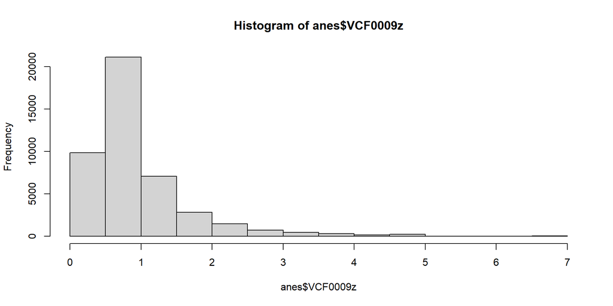

### Weights from scratch

Anywhere you would normally count the number of observations, sum the weight variable:

```r
anes|>
  select(trust_media,VCF0009z)|>
  drop_na()|>
  group_by(trust_media)|>
  summarize(n = n(),
            weighted_n = sum(VCF0009z)
            )
```

```
# A tibble: 5 × 3
  trust_media               n weighted_n
  <fct>                 <int>      <dbl>
1 None of the time        133       143.
2 Almost never           1140      1159.
3 Only some of the time  3607      3602.
4 Most of the time       2292      2242.
5 Just about always       335       325.
```

### Weights from scratch

Anywhere you would normally count the number of observations, sum the weight variable:

```r
anes|>
  select(trust_media,VCF0009z)|>
  drop_na()|>
  group_by(trust_media)|>
  summarize(n = n(),
            weighted_n = sum(VCF0009z)
            )|>
  mutate(proportion = n/sum(n),
         weighted_proportion = weighted_n/sum(weighted_n)
         )
```

```
# A tibble: 5 × 5
  trust_media               n weighted_n proportion weighted_proportion
  <fct>                 <int>      <dbl>      <dbl>               <dbl>
1 None of the time        133       143.     0.0177              0.0191
2 Almost never           1140      1159.     0.152               0.155
3 Only some of the time  3607      3602.     0.480               0.482
4 Most of the time       2292      2242.     0.305               0.300
5 Just about always       335       325.     0.0446              0.0435
```

### Weighted calculations

Some functions will automatically calculate weighted statistics if you just supply the weight variable:

```r
anes|>
  select(trust_media,VCF0009z)|>
  drop_na()|>
  count(trust_media, wt=VCF0009z)|>
  mutate(proportion = n/sum(n))
```

```
# A tibble: 5 × 3
  trust_media               n proportion
  <fct>                 <dbl>      <dbl>
1 None of the time       143.     0.0191
2 Almost never          1159.     0.155
3 Only some of the time 3602.     0.482
4 Most of the time      2242.     0.300
5 Just about always      325.     0.0435
```

### Weighted calculations

Some functions will automatically calculate weighted statistics if you just supply the weight variable:

```r
anes|>
  mutate(fem_therm = replace(VCF0253, VCF0253>97, NA))|>
  summarize(
    weighted_fem_therm = weighted.mean(fem_therm, w=VCF0009z, na.rm=T),
    fem_therm = mean(fem_therm,  na.rm=T)

    )
```

```
# A tibble: 1 × 2
  weighted_fem_therm fem_therm
               <dbl>     <dbl>
1               55.4      56.0
```

### srvyr

`srvyr` is a specialized R package for handling survey data. Using `as_survey_design` will create a new data set with a weighting attribute that is automatically applied when we use other functions from the package.

```r
library(srvyr)

anes_svy <-
  anes|>
  as_survey_design(ids = 1, weight =  VCF0009z)
```

### srvyr

For instance, we can get weighted proportions:

```r
anes_svy|>
  select(trust_media)|>
  drop_na()|>
  group_by(trust_media)|>
  summarize(proportions = survey_prop())
```

```
# A tibble: 5 × 3
  trust_media           proportions proportions_se
  <fct>                       <dbl>          <dbl>
1 None of the time           0.0191        0.00188
2 Almost never               0.155         0.00496
3 Only some of the time      0.482         0.00663
4 Most of the time           0.300         0.00602
5 Just about always          0.0435        0.00266
```

### srvyr

Or weighted averages:

```r
anes_svy|>
  mutate(fem_therm = replace(VCF0253, VCF0253>97, NA))|>
  summarize(avg = survey_mean(fem_therm, na.rm=T))
```

```
# A tibble: 1 × 2
    avg avg_se
  <dbl>  <dbl>
1  55.4  0.188
```

### srvyr

`gtsummary` provides some additional functions for working with the `srvyr` package, so we can automatically create nicely formatted tables with survey results:

```r
anes_svy|>
  select(trust_media)|>
  tbl_svysummary(include = trust_media,
                 label=list(trust_media='Trust media')
                 )
```

| **Characteristic** | **N = 44,308**<sup>1</sup> |
| --- | --- |
| Trust media |  |
| None of the time | 143 (1.9%) |
| Almost never | 1,159 (16%) |
| Only some of the time | 3,602 (48%) |
| Most of the time | 2,242 (30%) |
| Just about always | 325 (4.4%) |
| Unknown | 36,837 |

<sup>1</sup> n (%)

### Try it out

Get the weighted average of the symbolic racism index by federal spending preferences.

(You’ll probably need to `drop_na()` values to avoid an error message here)

```r
anes_svy|>
  select(sr_index, fedspending_poor)|>
  drop_na()
```

```r
anes_svy|>
  select(sr_index, fedspending_poor)|>
  drop_na()|>
  tbl_svysummary(include = sr_index,
                 by =fedspending_poor
                 )
```

| **Characteristic** | **1. Increased** N = 13,568<sup>1</sup> | **2. Same** N = 10,434<sup>1</sup> | **3. Decreased** N = 3,435<sup>1</sup> |
| --- | --- | --- | --- |
| sr_index | 11.0 (7.0, 14.0) | 14.0 (11.0, 17.0) | 16.0 (13.0, 19.0) |

<sup>1</sup> Median (Q1, Q3)

## Alternative data formats

- Data formats like `.sav`, `.dta` are intended for use with stats software like Stata and SPSS. These can handle a lot of additional features not included in a `.csv` file.
- Importantly, they have varying levels of support for factor labels. Importing data in these formats *can* save us from some of the recoding steps.
- However, you’ll occasionally see some weird behaviors when working with these formats in R, so be careful.

### Stata format

I can use the `haven` package to read the `Stata` formatted file. Now, just using `as_factor` on a variable will automatically give me a factor variable:

```r
file<-here::here("Data", "anes_timeseries_cdf_stata_20260205.zip")
anes_dta<-haven::read_dta(file)

anes_dta|>
  mutate(trust_media =as_factor(VCF0675))|>
  count(trust_media)
```

```
# A tibble: 8 × 2
  trust_media                   n
  <fct>                     <int>
1 1. Just about always        335
2 2. Most of the time        2292
3 3. Only some of the time   3607
4 4. Almost never            1140
5 5. None of the time [VOL]   133
6 8. DK                        23
7 9. NA; no Post IW           806
8 <NA>                      65409
```

### Stata format

Stata formatted data can also contain separate labels for each variable, so we can see the text of each question here:

```r
attr(anes_dta$VCF0675, "label")
```

```
[1] "How Much of the Time Does Respondent Trust the Media to Report Fairly"
```

### Stata format

Some R commands can automatically make use of variable labels, which can be convenient or annoying depending on the situation.

```r
anes_dta|>
  mutate(trust_media  =as_factor(VCF0675))|>
  select(trust_media)|>
  tbl_summary()
```

| **Characteristic** | **N = 73,745**<sup>1</sup> |
| --- | --- |
| How Much of the Time Does Respondent Trust the Media to Report Fairly |  |
| 1. Just about always | 335 (4.0%) |
| 2. Most of the time | 2,292 (27%) |
| 3. Only some of the time | 3,607 (43%) |
| 4. Almost never | 1,140 (14%) |
| 5. None of the time [VOL] | 133 (1.6%) |
| 8. DK | 23 (0.3%) |
| 9. NA; no Post IW | 806 (9.7%) |
| Unknown | 65,409 |

<sup>1</sup> n (%)

### Making a formatted table with gtsummary

```r
anes_dta|>
  mutate(trust_media  =as_factor(VCF0675))|>
  select(trust_media)|>
  drop_na()|>
  tbl_likert()
```

| **Characteristic** | **1. Just about always** | **2. Most of the time** | **3. Only some of the time** | **4. Almost never** | **5. None of the time [VOL]** | **8. DK** | **9. NA; no Post IW** |
| --- | --- | --- | --- | --- | --- | --- | --- |
| How Much of the Time Does Respondent Trust the Media to Report Fairly | 335 (4.0%) | 2,292 (27%) | 3,607 (43%) | 1,140 (14%) | 133 (1.6%) | 23 (0.3%) | 806 (9.7%) |

### Making a formatted table with gtsummary

```r
library(labelled)
varlabs<-lapply(anes_dta, function(x) attr(x, 'label'))
datasubset <- anes_dta |>
  filter(VCF0004 ==2024) |>
  filter(VCF0303>0)|>
  select(VCF0205:VCF0207, VCF0209:VCF0212, VCF0009z, VCF0303) |>
  mutate(across(VCF0205:VCF0212, .fn =  ~ as.numeric(replace(.x, .x >
                                                               97, NA))),
         VCF0303 = as_factor(VCF0303))|>
  droplevels()
var_label(datasubset)<-varlabs[colnames(datasubset)]

datasubset|>
  as_survey_design(ids = 1, weight =  VCF0009z)|>
  select(-VCF0009z)|>
  drop_na()|>
  tbl_svysummary(by = VCF0303)
```

| **Characteristic** | **1. Democrats (including leaners)** N = 2,127<sup>1</sup> | **2. Independents** N = 264<sup>1</sup> | **3. Republicans (including leaners)** N = 1,890<sup>1</sup> |
| --- | --- | --- | --- |
| Thermometer - Jews | 70 (50, 90) | 50 (50, 75) | 70 (50, 85) |
| Thermometer - Blacks | 80 (60, 97) | 50 (50, 75) | 60 (50, 85) |
| Thermometer - Whites | 70 (50, 85) | 50 (50, 75) | 70 (50, 85) |
| Thermometer - Big Business | 40 (20, 50) | 50 (30, 50) | 50 (40, 65) |
| Thermometer - Labor Unions | 70 (50, 85) | 50 (50, 70) | 50 (40, 60) |
| Thermometer - Liberals | 60 (50, 85) | 50 (40, 50) | 35 (15, 50) |
| Thermometer - Conservatives | 40 (15, 50) | 50 (45, 50) | 70 (50, 85) |

<sup>1</sup> Median (Q1, Q3)